# Interactions between cardiac activity and conscious somatosensory perception

Paweł Motyka (pawel.motyka@psych.uw.edu.pl)

Semptember 25th 2018

**List of sections**:

1. Load required packages and preprocess behavioral data S1
2. Determine the relative positions of stimulus onsets within the cardiac cycle S2
3. Determine the length of individual cardiac phases (T-wave end detection algorithm) S3
4. Show descriptive statistics of behavioral data S4
5. Test unifromity of stimulus onsets distribution within the cardiac cycle for each participant S5
6. Test unifromity of hits and misses distributions within the cardiac cycle (Figure 2AB) S6
7. Filter out outlying systole intervals S7
8. Test differences in mean hit rates between systole and diastole (Figure 3) S8
9. Test Pre- and post-stimulus heart rate for hits and misses (Figure 4A) S9
10. Test differences in the extent of cardiac deceleration between hits and misses (Figure 4B) S10

**1. Load required packages and preprocess behavioral data**

```r
# Specify data directory
data_dir <- 'N:/CCSomato_data'
setwd(data_dir)

# load behavioral data
data <- read.table("CCSomato_trials.txt", header = TRUE, sep = "\t", fill = TRUE, stringsAsFactors = FALSE)

## description of the crucial variables in behavioral data file:
  # "stim_type" - stimulus type (1 - near-treshold, 0 - catch trial)
  # "resp1" - response (1 - "yes", 0 - "no")
  # "resp1_t" - response time [in seconds]
  # "stim_onset" - stimulus onset time (in seconds)
  # "ao_error": specfiying whether recording error has occurred (1 - "yes", 0 - "no") - while collecting data from 12th participant, the data acquisition card produced an error (and stopped the recording). We recorded the occurence of the error, which happened in 15 trials that have been later excluded. For the first 11 participants we assigned value 0 as no error has occurred.
data$ao_error[is.na(data$ao_error)] <- 0

# exclude participant 01 (one of the authors tested during the final pilot)
data <- data[!(data$ID == 1),]

# exclude one block due to an ECG recording error in this block
data <- data[!(data$ID == 4 & data$block == 1), ]


## Classify responses

# classify as a hit in case of the stimulus present and "yes" response
data$resp_class[data$stim_type == 1 & data$resp1 == 1] <- 'hit'

# classify as a miss in case of the stimulus present and "no" response
data$resp_class[data$stim_type == 1 & data$resp1 == 0] <- 'miss'

# classify as a false alarm in case of the catch trial and "yes" response
data$resp_class[data$stim_type == 0 & data$resp1 == 1] <- 'FA'

# classify as a correct rejection in case of the catch trial and "no" response
data$resp_class[data$stim_type == 0 & data$resp1 == 0] <- 'CR'

# save response class variable as a factor
data$resp_class <- factor(data$resp_class)
```

**2. Determine the relative positions of stimulus onsets within the cardiac cycle**

```r
# load required packages
require(R.matlab, warn.conflicts = FALSE, quietly=TRUE)

# specify ECG files prefix
file_prefix <- 'CCSomato_'

# specify a data frame with the number of ECG events
ecg_events_list <- data.frame(ID = integer(0),
                              block = integer(0),
                              ecg_event_num = numeric(0))

### LOOP PARTICIPANTS (p)

for (p in unique(data$ID)) {ifelse(p < 10, ID_str <- paste('0', p, sep = ''), ID_str <- p)

  ## LOOP BLOCKS (b)

    for (b in unique(data$block[data$ID==p])) {

    # specify directories containing ECG data
    kubios_mat <- paste(data_dir, '/ID', ID_str, '/ecg/kubios/', file_prefix, ID_str, '_exp_0', b,'_hrv','.mat', sep='')
    ecg_event_file <- paste(data_dir, '/ID', ID_str, '/ecg/eeg_lab/', file_prefix, ID_str, '_events_exp_0', b, '.csv', sep='')

    # specify ECG sampling frequency (in Hz)
    ecg_sf <- 1000

    # load the vectors with R-peaks time series from Kubios matlab files into R
    R_peaks_tmp <- readMat(kubios_mat)
    R_peaks <- as.vector(R_peaks_tmp$Res[[4]][[2]][[2]]) # the numbers in the list reflect the position of R peaks data in Kubios matlab files
    rm(R_peaks_tmp)

    # import markers of events/responses from ECG file
    ecg_events <- read.csv(ecg_event_file, sep = '\t')

    # import a vector with stimulus onset time series (in seconds)
    stim_onsets <- ecg_events$latency[ecg_events$type=='S  1']/ecg_sf

    # subset a vector with the sequence of trials (stimulation or catch trial)
    sequence <- subset(data, ID==p & block==b, stim_type)

    # subset a vector with the sequence of responses ("yes" or "no")
    responses <- subset(data, ID==p & block==b, resp1)

        # LOOP TRIALS (tr)

        # specify variables computed in the loop on the trial level (variables are described below within the loop)
        pos <- c()
        diff2peak <- c()
        diff2peak_deg <-c()
        diff2peak_abs <-c()
        RR_interval <- c()
        stim_degree <- c()
        ecg_i <- 0

        for (tr in 1:120) { # 120 - number of trials per block

          # perform further computations while skipping the trials when the ao_error occurred
          if (data$ao_error[data$ID == p & data$block == b & data$trial == tr] == 1)
          {data$diff2peak_deg[data$ID == p & data$block == b & data$trial == tr] <- NA}
          else {ecg_i <- ecg_i+1

              # encode the time of the R peak before the stimulus onset
              pos[ecg_i] <- max(which(R_peaks < stim_onsets[ecg_i]))

              # encode the difference between the stimulus onset time and the previous R peak
              diff2peak[ecg_i] <- stim_onsets[ecg_i] - R_peaks[pos[ecg_i]]

              # encode tha duration of the RR interval during which the stimulus occurred
              RR_interval[ecg_i] <- (R_peaks[pos[ecg_i]+1] - R_peaks[pos[ecg_i]])

              # encode the relative position of stimulus onset within the RR interval, assigning the values from 0 to 360 degrees (with 0 indicating the R peak previous to the stimulus onset).
              stim_degree[ecg_i] <- 360 * diff2peak[ecg_i]/(R_peaks[pos[ecg_i]+1] - R_peaks[pos[ecg_i]])

              # add a variable specifying the relative position of stimulus within the RR interval
              data$diff2peak_deg[data$ID == p & data$block == b & data$trial == tr] <- stim_degree[ecg_i]

              # add a variable specifying the absolute difference between the stimulus onset and the previous R peak (in seconds)
              data$diff2peak_abs[data$ID == p & data$block == b & data$trial == tr] <- diff2peak[ecg_i]

              # add the "RR interval" variable (in seconds)
              data$RR_interval[data$ID == p & data$block == b & data$trial == tr] <- RR_interval[ecg_i]

            #add the sequence of pre- and post-stimulus RR intervals for each trial

            # Stimulus - 2
    data$RR_int_minus2[data$ID == p & data$block == b & data$trial == tr] <- (R_peaks[pos[ecg_i]-1] - R_peaks[pos[ecg_i]-2])

            # Stimulus - 1
    data$RR_int_minus1[data$ID == p & data$block == b & data$trial == tr] <- (R_peaks[pos[ecg_i]] - R_peaks[pos[ecg_i]-1])

            # Stimulus
    data$RR_int_zero_stimulus[data$ID == p & data$block == b & data$trial == tr] <- (R_peaks[pos[ecg_i]+1] - R_peaks[pos[ecg_i]])

            # Stimulus + 1
    data$RR_int_plus1[data$ID == p & data$block == b & data$trial == tr] <- (R_peaks[pos[ecg_i]+2] - R_peaks[pos[ecg_i]+1])

            # Stimulus + 2
    data$RR_int_plus2[data$ID == p & data$block == b & data$trial == tr] <- (R_peaks[pos[ecg_i]+3] - R_peaks[pos[ecg_i]+2])

            # Stimulus + 3
    data$RR_int_plus3[data$ID == p & data$block == b & data$trial == tr] <- (R_peaks[pos[ecg_i]+4] - R_peaks[pos[ecg_i]+3])


              } # END: perform computations skipping the trials when the ao_error occurred

        } # END: LOOP TRIAL (tr)

    # Create data frame with ECG events
    ecg_events_list[nrow(ecg_events_list)+1,] <- c(p,b,length(stim_onsets))

    } ## END: LOOP BLOCKS (b)

} ### END: LOOP PARTICIPANTS (p)

# remove the objects used within the loop
rm(responses)
rm(ecg_events)
rm(sequence)

## Saving and loading the processed data
#write.table(data, file = "CCSomato_ECG_data(output_from_section_2)", sep = "\t")
```

**3. Determine the length of individual cardiac phases (T-wave end detection algorithm)**

```r
#data <- read.table("CCSomato_ECG_data(output_from_section_2)", header = TRUE, sep = "\t", fill = TRUE, stringsAsFactors = FALSE)

## T-wave end detection - Trapez area algorithm (Vázquez-Seisdedos et al., 2011)

# To segment the cardiac cycle into systole and diastole, we computed the trial-specific phases based on cardio-mechanical events related to the ECG trace. The ventricular systolic phase (further referred as "systole") was defined as a time between R peak of the QRS complex and the t-wave end, while diastole as the remaining part of the RR interval. The trapez area algorithm was applied to encode the t-wave end in each trial. First, the t-peak was located as a local maximum within the – physiologically plausible – interval after the R peak containing the t-wave. Subsequently, the algorithm computed a series of trapezes along the descending part of the t-wave signal, defining the point at which the trapezium’s area gets maximal as the t-wave end (implementation of T-wave end alogorithm: Esra Al & Pawel Motyka).

# specify ECG sampling frequency (in Hz)
fs <- 1000

# LOOP PARTICIPANTS (s)
for (s in unique(data$ID)){
 ifelse(s < 10, ID_str<-paste('0', s, sep = ''), ID_str<-s)

  # LOOP BLOCKS (b)

  for (b in unique(data$block[data$ID == s])) {

    # subset observations
    data_bl <- data[data$ID == ID_str & data$block == b, ]

    # load ECG data (fllowing the structure described in the previous section)
    ECG_name <- paste(data_dir, '/ID', ID_str, '/ecg/filtecg/filtECGID', ID_str,'_',b, '.txt', sep='')
    ECG <- read.table(ECG_name)
    ECG[,2] <- -ECG[,2]
    kubios_name <- paste(data_dir, '/ID', ID_str, '/ecg/kubios/', 'CCSomato_', ID_str, '_exp_0', b,'_hrv','.mat', sep='')
    R_peaks<- readMat(kubios_name)
    R_peaks<- as.vector(R_peaks$Res[[4]][[2]][[2]])
    ecg_event_file <- paste(data_dir, '/ID', ID_str, '/ecg/eeg_lab/', 'CCSomato_', ID_str, '_events_exp_0', b, '.csv', sep='')
    ecg_events <- read.csv(ecg_event_file, sep = '\t')

    # import a vector with stimulus onset time (in seconds)
    stim_onsets <- ecg_events$latency[ecg_events$type=='S  1']/fs

    # specify variables used in the loops
    ecg_i <- 0
    pos <- c()
    ecgpos1 <- c()
    ecgpos2 <- c()
    RRint <- c()

    # LOOP TRIALS (ind)

    for (ind in 1:120) {

      # perform further computations while skipping the trials when the ao_error occurred
      if (data$ao_error[data$ID == s & data$block == b & data$trial == ind] == 1) {

      ## add "NA" in case of ao_error

      # T-wave end
      data$tend[data$ID == s & data$block == b & data$trial == ind] <- NA

      # Systole length
      data$systolength[data$ID == s & data$block == b & data$trial == ind] <- NA

      # Stimulus at systole - True/False
      data$systole[data$ID == s & data$block == b & data$trial == ind] <- NA

      } else {

      # for the trials after ao_error occurence take the next datapoint from ECG data vectors
      ecg_i <- ecg_i + 1

      # calculate the position of R peak that occured just before the stimulus onset
      pos[ecg_i] <- max(which(R_peaks < stim_onsets[ecg_i]))

      # calculate the position of R peak that occured just before the stimulus onset in data points in the R_peaks vector
      ecgpos1[ecg_i] <- R_peaks[pos[ecg_i]]*fs

      # calculate the duration of RR interval containing the stimulus in data points
      RRint[ecg_i] <- (R_peaks[pos[ecg_i]+1]-R_peaks[pos[ecg_i]])*fs

      # Calculate a time interval where the end of t wave would be included (in data points). Cut off fs*(150/2500) data points so that t wave max calculation would not detect the next R peak.
      ecgpos2[ecg_i] <- ecgpos1[ecg_i]+RRint[ecg_i]-150*(fs/2500)

      # create a vector containing all possible data points in the RR interval for visualization purposes. 120 ms or fs*(300/2500) data points are chosen arbitrarily to include the Rpeaks in the plots.
      twave1 <- ECG[(ecgpos1[ecg_i]-300*(fs/2500)):ecgpos2[ecg_i]+300*(fs/2500),]

       # create a vector (twave) where the maximum of t wave could be calculated. After visually observing a block of each participant, it is decided that tmax should occur at least after 350/2500 ms after the R peak. In order to calculate the position of tmax, delete (350/2500)*fs data points from the end of RRint vector and search it until the 1/3 of the remaining vector. 1/3 ratio was given to compensate for the variation of trial to trial RR interval durations.
      twave <- ECG[(ecgpos1[ecg_i]+350*(fs/2500)):ecgpos2[ecg_i],]
      tmaxpos <- which.max(twave[1:((RRint[ecg_i]-350*(fs/2500))/3),2])

      # calculate a snip of t wave which starts with the tmax
      twave2 <- twave[tmaxpos:dim(twave)[1],]

      # Determine a point called xm located in the segment after the T peak, which has a minimum value in the first derivative. The algoritm searces for xm in a 120 ms time window startng from tmax. In case twave2 does not contain 0.12*fs data points, it searches only until the last point of twave2.
      dp <- 0.12*fs # 0.12 s in data points
      if (dp>dim(twave2)[1]) {
        xm <- which(diff(twave2[,2])==min(diff(twave2[,2])))
      } else {
        xm <- which(diff(twave2[1:dp,2])==min(diff(twave2[1:dp,2])))
      }
      xm <- xm[1]
      ym <- twave2[xm,2]

      # determine a point xr which is supposed t happen after tend.
      xr <- 150+xm

      # make a vector starting from xm and goes until xr
      xseq <- xm:xr
      yseq <- twave2[xm:xr,2]

      # write a function find the end of twave: first calculation of the trapeziums areas of all the points located between “xm“ and “xr“ and then identification of the point which gives the maximum area and label it as the t-wave end
      trapez_area <- function(xm, ym, xseq, yseq, xr) {
        a <- numeric()
        for (i in seq_along(xseq)){
          a[i] <- 0.5 * (ym - yseq[i]) * ((2*xr) - xseq[i] - xm)
        }
        x_tend <- which.max(a)+xm-1
        return(x_tend)
      }
      tend <- trapez_area(xm, ym, xseq, yseq, xr)

      ## Optional: Plot visualizations of T-wave end for each trial and export them as jpg files
      # par(mfrow=c(1,2))
      # jpeg(file = paste('subject ',s,'_block ',b,'_trial ', ind,".jpg"))
      # plot(twave1,col='black',xlab='time(ms)', ylab='electrical potential(mV)')
      # points(twave[tmaxpos,1],twave[tmaxpos,2],col='magenta',pch='+',cex=2)
      # points(twave2[tend,1],twave2[tend,2],col='green',pch='+',cex=2)
      # plot(twave2,col='black', xlab='time(s)', ylab='electrical potential(mV)')
      # title(paste('subject ',s,'_block ',b,'_trial ', ind, sep=''),line=-2, outer=TRUE)
      # points(twave2[xm,1],twave2[xm,2],col='blue',pch='+',cex=2)
      # points(twave2[xr,1],twave2[xr,2],col='blue',pch='+',cex=2)
      # points(twave2[tend,1],twave2[tend,2],col='green',pch='+',cex=2)
      # points(twave[tmaxpos,1],twave[tmaxpos,2],col='magenta',pch='+',cex=2)
      # title(paste('subject ',s,'_block ',b,'_trial ', ind, sep=''),line=-2, outer=TRUE)
      # dev.off()

      # Add the t-wave end to data frame
      data$tend[data$ID == s & data$block == b & data$trial == ind] <- twave2[tend,1]

      # Add systole length to data frame
      data$systolength[data$ID == s & data$block == b & data$trial == ind] <- twave2[tend,1]-R_peaks[pos[ecg_i]]

      # Specify whether stimulus onset occurred within the systole interval
      data$systole[data$ID == s & data$block == b & data$trial == ind] <- stim_onsets[ecg_i]<twave2[tend,1]

      } # END: "IF-ELSE" CONDITIONAL LOOP

    } # END: LOOP TRIALS (ind)

  } # END: LOOP BLOCKS (b)

} # END: LOOP PARTICIPANTS (s)

## Save the processed data
#write.table(data, file = "CCSomato_ECG_data(output_from_section_3)", sep = "\t")
```

**4. Show descriptive statistics of behavioral data**

```r
#data <- read.table("CCSomato_ECG_data(output_from_section_3)", header = TRUE, sep = "\t", fill = TRUE, stringsAsFactors = FALSE)

## Perform exclusions of individual trials

# remove 15 trials in which ao_error occurred and onset position was not calculated
length(data$ao_error[data$ao_error == 1])
```

```
## [1] 15
```

```r
data <- data[!(data$ao_error == 1),]

# remove 2 trials with outlying RR intervals lengths (i.e. ~2.1 and ~3.4 seconds) observed due to missed fragments of ECG signal. The third longest interval equaled ~ 1.26 sec.
length(data$RR_interval[data$RR_interval > 1.27])
```

```
## [1] 2
```

```r
data <- data[!(data$RR_interval > 1.27),]

# remove 191 trials in which participants did not give any response within 2 seconds
length(data$resp1_t[data$resp1_t >= 2])
```

```
## [1] 191
```

```r
data <- data[!(data$resp1_t >= 2),]

# remove 2 trials in which participants pressed a wrong button (target buttons were: 2 and 3)
length(data$resp1_btn[data$resp1_btn < 2 | data$resp1_btn > 3])
```

```
## [1] 2
```

```r
data <- data[!(data$resp1_btn < 2 | data$resp1_btn > 3),]

# show remaining number of the trials after exclusions
length(data$trial)
```

```
## [1] 11550
```

```r
# Specify a data frame with the set of behavioral variables
data_behav <- data.frame(ID = integer(0),
              age = integer(0),
              hit = numeric(0),
              miss = numeric(0),
              FA = numeric(0),
              CR = numeric(0),
              hit_rate = numeric (0),
              FA_rate = numeric(0))

# LOOP PARTICIPANTS (p)

for (p in unique(data$ID)) {

     #age
     age <- unique(data$age[data$ID == p])

     # count hits
     hit <- length(data$resp_class[data$resp_class =="hit" & data$ID == p])

     # count misses
     miss <- length(data$resp_class[data$resp_class =="miss" & data$ID == p])

     # count false alarms
     FA <- length(data$resp_class[data$resp_class =="FA" & data$ID == p ])

     # count correct rejections
     CR <- length(data$resp_class[data$resp_class =="CR" & data$ID == p ])


     # calculate hit rate (varying from 0 to 1)
     hit_rate <- (length(data$resp_class[data$resp_class =="hit" & data$ID == p]))/(length(data$trial[data$ID == p & data$stim_type == 1]))

     # calculate false alarms rate (varying from 0 to 1)
      FA_rate <- (length(data$resp_class[data$resp_class =="FA" & data$ID == p]))/(length(data$trial[data$ID == p & data$stim_type == 0]))

     # create a data frame with the abovementioned variables
      data_behav[nrow(data_behav)+1,] <- c(p, age, hit, miss, FA, CR, hit_rate, FA_rate)

    } # END: LOOP PARTICIPANTS (p)

# show basic statistics for hit rate
mean(data_behav$hit_rate)
```

```
## [1] 0.4679088
```

```r
median(data_behav$hit_rate)
```

```
## [1] 0.4533333
```

```r
sd(data_behav$hit_rate)
```

```
## [1] 0.1625485
```

```r
range(data_behav$hit_rate)
```

```
## [1] 0.1515152 0.7939189
```

```r
# show basic statistics for false alarms rate
mean(data_behav$FA_rate)
```

```
## [1] 0.04229545
```

```r
median(data_behav$FA_rate)
```

```
## [1] 0.01694915
```

```r
sd(data_behav$FA_rate)
```

```
## [1] 0.05726849
```

```r
range(data_behav$FA_rate)
```

```
## [1] 0.0000000 0.1666667
```

```r
# show basic statistics for age
mean(data_behav$age)
```

```
## [1] 25.93939
```

```r
range(data_behav$age)
```

```
## [1] 19 36
```

```r
sd(data_behav$age)
```

```
## [1] 4.092214
```

```r
# show a total number of valid trials
length(data$trial)
```

```
## [1] 11550
```

```r
length(data$trial[data$resp_class == "hit"])
```

```
## [1] 4530
```

```r
length(data$trial[data$resp_class == "miss"])
```

```
## [1] 5104
```

```r
length(data$trial[data$resp_class == "FA"])
```

```
## [1] 81
```

```r
length(data$trial[data$resp_class == "CR"])
```

```
## [1] 1835
```

```r
#Stimulus intensity (summary)
stim_int <- data.frame(ID = integer(0),
                              block = integer(0),
                              intensity = numeric(0))

### LOOP PARTICIPANTS (p)
for (p in unique(data$ID)) {

  ## LOOP BLOCKS (b)
    for (b in unique(data$block[data$ID==p])) {
   ID <- p
   block <- b
   intensity <- mean(data$intensity[data$ID == p & data$block == b & data$stim_type ==1])
    stim_int[nrow(stim_int)+1,] <- c(p,b,intensity)

    } ## END: LOOP BLOCKS (b)
} ### END: LOOP PARTICIPANTS (p)

M_int <- mean(stim_int$intensity)
SD_int <- sd(stim_int$intensity)
range_int <- range(stim_int$intensity)

## Save the processed data
#write.table(data, file = "CCSomato_ECG_data(output_from_section_4)", sep = "\t")
```

**5. Test unifromity of stimulus onsets distribution within the cardiac cycle for each participant**

```r
#data <- read.table("CCSomato_ECG_data(output_from_section_4)", header = TRUE, sep = "\t", fill = TRUE, stringsAsFactors = FALSE)

# load required packages
require(circular, warn.conflicts = FALSE, quietly=TRUE)

## General information about the Rayleigh Test (Circular Statistics)
#"Rayleigh Test of Uniformity" assess the significance of the mean resultant length (—R) which is "a measure of the concentration of data points around the circle. If —R is greater than a threshold value, the data are interpreted as being too concentrated to be consistent with uniformity" (Pawsey et al., 2013, s. 81). The alternative hypothesis is a unimodal distribution with unknown mean direction. For more details on using circular statistics in R please see: https://cran.r-project.org/web/packages/circular/circular.pdf

# specify a data frame with the uniformity test results for each participant
Onset_distribution_ID <- data.frame(ID = integer(0),
                              test_statistics = numeric(0),
                              p_value = numeric(0))

for (p in unique(data$ID)) { # LOOP PARTICIPANTS (p)

  # save the vector with calculated onset positions in degrees as a circular object
  temp_onset <- circular(data$diff2peak_deg[data$ID==p], type="angles", units="degree", rotation="clock", zero=pi/2)

   ## Optional: plot the distribution of stimulus onsets within the RR intervals for each participant - with 0 indicating the R peak before stimulus onset
  #plot(temp_onset, stack=TRUE, col = "gray25", cex = 0.77, main = paste("Onset distibution \n participant nr", p))
  #rose.diag(temp_onset, bins = 16, col = "cadetblue4", prop = 2.5, add = T, axes = F)
  #circ.dens = density(temp_onset, bw=40)
  #lines(circ.dens, col="lightcyan3", lwd = 3, xpd=TRUE)

  # test uniformity of onset distribution for a particpant and save the results
  onset_distribution_individual <- rayleigh.test(temp_onset)

  # show test statistics and p-value for a participant
  participant <- paste("ID", p)
  print(participant)
  print(onset_distribution_individual)

  # add test statistics and p-value to the data frame with uniformity testing results
  p_value <- onset_distribution_individual$p.value
  test_statistics <- onset_distribution_individual$statistic
  Onset_distribution_ID[nrow(Onset_distribution_ID)+1,] <- c(p, test_statistics, p_value)

}
```

```
## [1] "ID 2"
##
##        Rayleigh Test of Uniformity
##        General Unimodal Alternative
##
## Test Statistic:  0.0359
## P-value:  0.6349
##
## [1] "ID 3"
##
##        Rayleigh Test of Uniformity
##        General Unimodal Alternative
##
## Test Statistic:  0.0774
## P-value:  0.1194
##
## [1] "ID 4"
##
##        Rayleigh Test of Uniformity
##        General Unimodal Alternative
##
## Test Statistic:  0.0387
## P-value:  0.6985
##
## [1] "ID 5"
##
##        Rayleigh Test of Uniformity
##        General Unimodal Alternative
##
## Test Statistic:  0.0254
## P-value:  0.7951
##
## [1] "ID 6"
##
##        Rayleigh Test of Uniformity
##        General Unimodal Alternative
##
## Test Statistic:  0.0436
## P-value:  0.5085
##
```

[output cut: 208 more lines]

```
## [1] "ID 33"
##
##        Rayleigh Test of Uniformity
##        General Unimodal Alternative
##
## Test Statistic:  0.0066
## P-value:  0.9845
##
## [1] "ID 34"
##
##        Rayleigh Test of Uniformity
##        General Unimodal Alternative
##
## Test Statistic:  0.0177
## P-value:  0.898
```

```r
# show participants with a non-uniform distribution of stimulus onset
Onset_distribution_ID$ID[Onset_distribution_ID$p_value < 0.05]
```

```
## [1] 12
```

```r
# remove participant nr 12 from circular analysis
data_Circ <- data[data$ID != 12,]
```

**6. Test unifromity of hits and misses distributions within the cardiac cycle (Figure 2AB)**

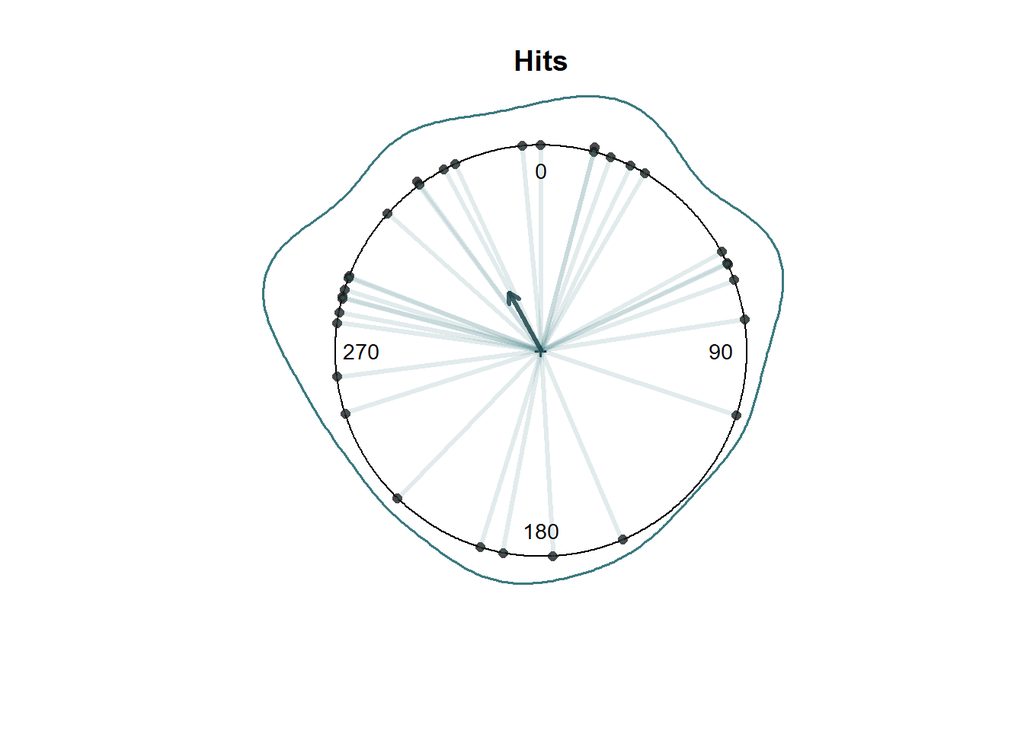

```r
# load required packages
require(scales, warn.conflicts = FALSE, quietly=TRUE)

## HITS


# specify a variable with the relative positions of hits within the RR intervals
mean_degree_hit <- vector()

# extract the list of participants
ID_list <- unique(data_Circ$ID)

for (p in ID_list) { # LOOP PARTICIPANTS (p)

  # save the vector with hits positions in degrees as a circular object
  temp_hit <- circular(data_Circ$diff2peak_deg[data_Circ$ID==p & data_Circ$resp_class == "hit"], type="angles", units="degree", rotation="clock", zero=0)

  # calculate the mean phase when hits occurred for each participant
  mean_degree_hit[p] <- mean(temp_hit)

} # END: LOOP PARTICIPANTS (p)

# save the vector with mean hits for each particiapant as a circular object
Hits_secondlevel <- circular(mean_degree_hit[ID_list], type="angles", units="degree", rotation="clock", zero=pi/2)

# plot the distribution of mean hits within the RR intervals - with 0 indicating the R peak previous to the stimulus onset
plot(Hits_secondlevel, stack= TRUE, bins = 720, col = alpha("gray10", 0.8), cex = 0.88, lwd = 2, main = "Hits")

# optionally add 'type = "n"' argument to eliminate points from the plot

# add lines representing mean hits for each participant
arrows.circular(Hits_secondlevel, col = rgb(0.23,0.48,0.50, 0.15), lwd = 3, length = 0.001)

# add an arrow representing grand mean for hits - with its length signifying resultant length of the grand mean
arrows.circular(mean(Hits_secondlevel), y=rho.circular(Hits_secondlevel), lwd = 3.3, col = rgb(0.13,0.28,0.30, 0.85), length = 0.08)

# add line signifying distribution of hits (bandwidth = 20)
circ.dens = density(Hits_secondlevel, bw=20)
lines(circ.dens, col= rgb(0.23,0.48,0.50), lwd = 1.5, type = "d", xpd=TRUE)
```

```r
# test uniformity of hits distribution within the RR intervals
rayleigh.test(Hits_secondlevel)
```

```
##
##        Rayleigh Test of Uniformity
##        General Unimodal Alternative
##
## Test Statistic:  0.3229
## P-value:  0.0343
```

```r
# show an angle of grand mean for hits
mean(Hits_secondlevel)
```

```
## Circular Data:
## Type = angles
## Units = degrees
## Template = none
## Modulo = asis
## Zero = 1.570796
## Rotation = clock
## [1] -28.64703
```

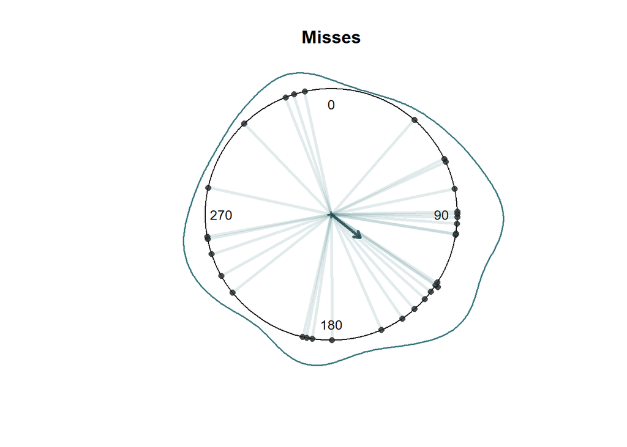

```r
## MISSES


# specify a variable with the relative positions of misses within the RR intervals
mean_degree_miss <- vector()

ID_list <- unique(data_Circ$ID)

for (p in ID_list) { # LOOP PARTICIPANTS (p)

  # save the vector with the mean misses for each particiapant as a circular object
  temp_miss <- circular(data_Circ$diff2peak_deg[data_Circ$ID==p & data_Circ$resp_class == "miss"], type="angles", units="degree",  rotation="clock", zero=0)

  # calculate the mean phase when misses occurred for each participant
  mean_degree_miss[p] <- mean(temp_miss)

} # END: LOOP PARTICIPANTS (p)

# save the vector with mean misses for each particiapant as a circular object
Miss_secondlevel <- circular(mean_degree_miss[ID_list], type ="angles", units ="degree", rotation ="clock", zero=pi/2)

# plot the distribution of mean misses within the RR intervals - with 0 indicating the R peak previous to the stimulus onset
plot(Miss_secondlevel, stack= TRUE, bins = 720, col = alpha("gray10", 0.8), cex = 0.88, lwd = 2, main = "Misses")

# optionally add 'type = "n"' argument to eliminate points from the plot

# add lines representing mean misses for each participant
arrows.circular(Miss_secondlevel, col = rgb(0.23,0.48,0.50, 0.15), lwd = 3, length = 0.001)

# add an arrow representing grand mean for misses - with its length signifying resultant length of the grand mean
arrows.circular(mean(Miss_secondlevel), y=rho.circular(Miss_secondlevel), lwd = 3.3, col = rgb(0.13,0.28,0.30, 0.85), length = 0.08)

# add line signifying distribution of misses (bandwidth = 20)
circ.dens = density(Miss_secondlevel, bw=20)
lines(circ.dens, col= rgb(0.23,0.48,0.50), lwd = 1.5, type = "d", xpd=TRUE)
```

```r
# test uniformity of misses distribution within RR intervals
rayleigh.test(Miss_secondlevel)
```

```
##
##        Rayleigh Test of Uniformity
##        General Unimodal Alternative
##
## Test Statistic:  0.2958
## P-value:  0.0598
```

```r
# show an angle of grand mean for misses
mean(Miss_secondlevel)
```

```
## Circular Data:
## Type = angles
## Units = degrees
## Template = none
## Modulo = asis
## Zero = 1.570796
## Rotation = clock
## [1] 128.8515
```

**7. Filter out outlying systole intervals**

```r
### Exclusion of outlying systole lengths defined as more than 4 standard deviations above or below the participant-specific mean

# Specify ID list
ID_list <- unique(data$ID)
# Specify data frame with the range of systole lengths (+/-4SD)
meansys <- matrix(data=NA,nrow=34,ncol=2)

## Identify minimal (-4SD) and maximal (+4D) acceptable systole length for each subject

# LOOP PARTICIPANTS (s)

for (s in ID_list){

  # threshold of 'minimal' systole length (-4SD)
  min_th <- mean(data$systolength[data$ID==s],na.rm=T) -4*sd(data$systolength[data$ID==s],na.rm=T)
  # save minimal threshold for participant
  meansys[s,1] <- min_th

  # threshold of 'maximal' systole length (+4SD) (+4SD)
  max_th <- mean(data$systolength[data$ID==s],na.rm=T) +4*sd(data$systolength[data$ID==s],na.rm=T)
  # save maximal threshold for participant
  meansys[s,2] <- max_th

} # END: LOOP PARTICIPANTS (s)

## Indetify trials with outyling systole lengths

# LOOP PARTICIPANTS (s)

# Vectors with the sum of outyling trials
below_4SD=c()
above_4SD=c()

for (s in ID_list){

  # Vectors with the outlying trials for each subject
  below_4SD_sub <- c()
  above_4SD_sub <- c()

  # Find outyling trials (-4SD) for each subject
  if (sum(data$ID[data$systolength < meansys[s,1] & data$ID==s], na.rm=T)>0) {
    below_4SD_sub <- cbind(data$ID[data$systolength < meansys[s,1] & data$ID==s ], data$block[data$systolength < meansys[s,1] & data$ID==s], data$trial[data$systolength < meansys[s,1] & data$ID==s])
  # Save these trials into a data frame with all outlying trials
    below_4SD <- rbind(below_4SD, below_4SD_sub)
  }

  # Find outyling trials (+4SD) for each subject
  if (sum(data$ID[data$systolength>meansys[s,2] & data$ID==s ],na.rm=T)) {
    above_4SD_sub <- cbind(data$ID[data$systolength>meansys[s,2] & data$ID==s ], data$block[data$systolength>meansys[s,2] & data$ID==s],data$trial[data$systolength>meansys[s,2] & data$ID==s])
  # Save these trials into data frame with all outlying trials
    above_4SD <- rbind(above_4SD, above_4SD_sub)
  }
}  # END: LOOP PARTICIPANTS (s)

# Create a list of all trials with outlying systole lengths
outlying_trials <- rbind(below_4SD, above_4SD)
outlying_trials <- na.omit(outlying_trials)
length(outlying_trials[,1])
```

```
## [1] 27
```

```r
# Exclude 27 trials with outlying lengths of systole
data_cor <- data
for (r in 1:nrow(outlying_trials)) {
  data_cor <- data_cor[!(data_cor$ID==outlying_trials[r,1] & data_cor$block==outlying_trials[r,2] & data_cor$trial==outlying_trials[r,3]),]
}

# Save the filtered data for binary analysis
data <- data_cor

## Saving and loading the processed data
#write.table(data, file = "CCSomato_ECG_data(output_from_section_7)", sep = "\t")
```

**8. Test differences in mean hit rates between systole and diastole (Figure 3)**

```r
#data <- read.table("CCSomato_ECG_data(output_from_section_7)", header = TRUE, sep = "\t", fill = TRUE, stringsAsFactors = FALSE)

# load required packages
require(ggplot2, warn.conflicts = FALSE, quietly=TRUE)
require(effsize, warn.conflicts = FALSE, quietly=TRUE)
require(scales, warn.conflicts = FALSE, quietly=TRUE)

## Create a data frame with hit rates for each participant

data_ID <- data.frame(ID = integer(0),
                 hit_rate = numeric (0),
                 hit_rate_s = numeric(0), # hit rate at systole
                 hit_rate_d = numeric(0)) # hit rate at diastole


for ( p in unique(data$ID)) { # LOOP PARTICIPANTS (p)

    # calculate hit rate
    hit_rate <- (length(data$resp_class[data$resp_class =="hit" & data$ID == p]))/(length(data$trial[data$ID == p & data$stim_type == 1]))


    # calculate hit rate at systole
    hit_rate_s <- (length(data$resp_class[data$resp_class =="hit" & data$ID == p & data$systole == T]))/(length(data$trial[data$ID == p & data$stim_type == 1 & data$systole == T]))

    # calculate hit rate at diastole
    hit_rate_d <- (length(data$resp_class[data$resp_class =="hit" & data$ID == p & data$systole == F]))/(length(data$trial[data$ID == p & data$stim_type == 1 & data$systole == F]))

    # add calculated varialbes to the data frame
    data_ID[nrow(data_ID)+1,] <- c(p, hit_rate, hit_rate_s,hit_rate_d)

} # END: LOOP PARTICIPANTS (p)

data_ID$hit_rate <- data_ID$hit_rate * 100
data_ID$hit_rate_s <- data_ID$hit_rate_s * 100
data_ID$hit_rate_d <- data_ID$hit_rate_d * 100

# test normality of hit rate distribution at systole and diastole
shapiro.test(data_ID$hit_rate_s)
```

```
##
##  Shapiro-Wilk normality test
##
## data:  data_ID$hit_rate_s
## W = 0.98529, p-value = 0.924
```

```r
shapiro.test(data_ID$hit_rate_d)
```

```
##
##  Shapiro-Wilk normality test
##
## data:  data_ID$hit_rate_d
## W = 0.97895, p-value = 0.7539
```

```r
# employ paired t-test to determine whether hit rate differs between the systole and diastole
t.test(data_ID$hit_rate_s, data_ID$hit_rate_d, mu = 0, alt = "two.sided", conf = 0.95, paired = T)
```

```
##
##  Paired t-test
##
## data:  data_ID$hit_rate_s and data_ID$hit_rate_d
## t = -2.761, df = 32, p-value = 0.009462
## alternative hypothesis: true difference in means is not equal to 0
## 95 percent confidence interval:
##  -4.9044024 -0.7401251
## sample estimates:
## mean of the differences
##               -2.822264
```

```r
# Calculate Cohen's d
cohen.d(data_ID$hit_rate_d, data_ID$hit_rate_s, paired = T)
```

```
##
## Cohen's d
##
## d estimate: 0.4806266 (small)
## 95 percent confidence interval:
##         inf         sup
## -0.01823044  0.97948363
```

```r
# show means for systole and diastole
mean(data_ID$hit_rate_s)
```

```
## [1] 45.10731
```

```r
sd(data_ID$hit_rate_s)
```

```
## [1] 16.34653
```

```r
mean(data_ID$hit_rate_d)
```

```
## [1] 47.92958
```

```r
sd(data_ID$hit_rate_d)
```

```
## [1] 16.54603
```

```r
# show number of participants with higher hit rate at diastole, systole
nrow(data_ID[data_ID$hit_rate_d > data_ID$hit_rate_s,])
```

```
## [1] 25
```

```r
nrow(data_ID[data_ID$hit_rate_d < data_ID$hit_rate_s,])
```

```
## [1] 8
```

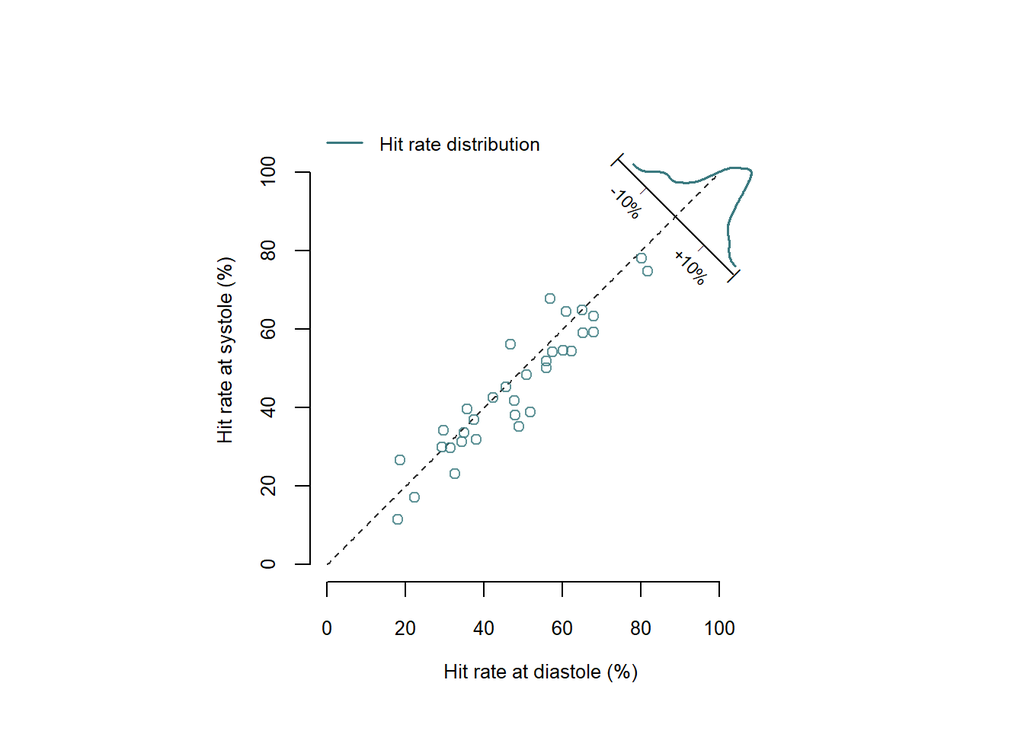

```r
## Plot hit rate at systole and diastole in reference to an identity line

# save data as vectors
hit_rate_s <- data_ID$hit_rate_s
hit_rate_d <- data_ID$hit_rate_d

# generate square plotting region
par(pty="s")

# specify plotting space
plot(c(0,109),c(0,109),type="n",xlab ="", ylab="", cex.lab = 0.8, cex.axis = 0.8, frame.plot = F)

title(ylab="Hit rate at systole (%)", line = 2.5, cex.lab= 0.8)
title(xlab="Hit rate at diastole (%)", line = 2.5, cex.lab= 0.8)

# create an identity line using a customized linear model
x<-0:100
y<-0:100
new <- data.frame(x = seq(0, 100, 0.5))
lines(new$x, predict(lm(y~x), new),col= alpha("black", alpha = 0.8),lty= 2, lwd = 1.3)

# plot the individual data
points(hit_rate_d,hit_rate_s, pch = 1, col = rgb(0.23,0.48,0.50, 0.8), cex = 1)

# prepare a matrix with hit rate distribution (difference between hit rate at systole and diastole)
diff <- as.matrix(data.frame(x=density(hit_rate_d-hit_rate_s)$x,y=density(hit_rate_d-hit_rate_s)$y))

# rescale y axis to match size of the plot
f <- scales::rescale(diff[,2], to = c(0, 20))
diff <- as.matrix(data.frame(x=density(hit_rate_d-hit_rate_s)$x,y=f))

# prepare rotation parameters
rotation_matrix <- matrix(c(cospi(1/4),sinpi(1/4),-sinpi(1/4),cospi(1/4)),ncol=2)

# rotate the matrix with hit rate distribution
diff_rotated <- diff %*% rotation_matrix

# plot hits rate distribution
lines((diff_rotated)+90, col = rgb(0.23,0.48,0.50), lwd = 1.7)

# create the x axis
lines(c(74,103.4),c(103.4,74), col = "black", cex = 1)

# define the coordinates representing the values plotted the x axis
points_coordinates <- matrix(c(1,0,-1,0),nrow=2,byrow=T)

# rotate the coordinates
points_coordinates_rotated <- points_coordinates %*% rotation_matrix

# add units to x axis
text(points_coordinates_rotated[1,1]+92,points_coordinates_rotated[1,2]+77,"+10%",srt=315,cex=.7)
text(points_coordinates_rotated[1,1]+103,points_coordinates_rotated[1,2]+74.7,"|",srt=315,cex=.8)
text(points_coordinates_rotated[2,1]+77,points_coordinates_rotated[2,2]+92,"-10%",srt=315,cex=.7)
text(points_coordinates_rotated[2,1]+74.7,points_coordinates_rotated[2,2]+103,"|",srt=315,cex=.8)

# add endpoints to x axis
text(points_coordinates_rotated[1,1]+94.7,points_coordinates_rotated[1,1]+80,"|",srt=315, cex= 0.35, col = "black")
text(points_coordinates_rotated[1,1]+80,points_coordinates_rotated[1,1]+94.7,"|",srt=315, cex= 0.35, col = "black")

# add legend
legend("topleft", "Hit rate distribution" , lty=1, col=rgb(0.23,0.48,0.50), lwd = 1.5, bty='n', cex=.79)
```

**9. Test Pre- and post-stimulus heart rate for hits and misses (Figure 4A)**

```r
#data <- read.table("CCSomato_ECG_data(output_from_section_7)", header = TRUE, sep = "\t", fill = TRUE, stringsAsFactors = FALSE)

# load required packages
require(ggplot2, warn.conflicts = FALSE, quietly=TRUE)
require(scales, warn.conflicts = FALSE, quietly=TRUE)
require(lme4, warn.conflicts = FALSE, quietly=TRUE)
require(tidyr, warn.conflicts = FALSE, quietly=TRUE)
require(afex, warn.conflicts = FALSE, quietly=TRUE)
require(plyr, warn.conflicts = FALSE, quietly=TRUE)
require(emmeans, warn.conflicts = FALSE, quietly=TRUE)

# Specify a data frame with pre- and post-stimulus RR Intervals seperately for hits and misses
data_ID <- data.frame(ID = integer(0),
                 RR_int_minus2_hit  = numeric(0), # S-2 hits
                 RR_int_minus1_hit  = numeric(0), # S-1 hits
                 RR_int_stimulus_hit = numeric(0), # Stimulus hits
                 RR_int_plus1_hit = numeric(0), # S+1 hits
                 RR_int_plus2_hit = numeric(0), # S+2 hits
                 RR_int_plus3_hit = numeric(0), #S+3 hits
                 RR_int_minus2_miss  = numeric(0), #S-2 misses
                 RR_int_minus1_miss  = numeric(0), #S-1 misses
                 RR_int_stimulus_miss = numeric(0), #Stimulus misses
                 RR_int_plus1_miss = numeric(0), #S+1 misses
                 RR_int_plus2_miss = numeric(0), #S+2 misses
                 RR_int_plus3_miss = numeric(0), #S+3 misss
                 RR_int_mean = numeric(0)) # Mean RR Interval

for ( i in unique(data$ID )) { # LOOP PARTICIPANTS (i)

# Calculate RR Intervals specified in the data frame (HITS)
    RR_int_minus2_hit <- mean(data$RR_int_minus2[data$ID == i & data$resp_class == "hit"])
    RR_int_minus1_hit <- mean(data$RR_int_minus1[data$ID == i & data$resp_class == "hit"])
    RR_int_stimulus_hit <- mean(data$RR_int_zero_stimulus[data$ID == i & data$resp_class == "hit"])
    RR_int_plus1_hit <- mean(data$RR_int_plus1[data$ID == i & data$resp_class == "hit"])
    RR_int_plus2_hit <- mean(data$RR_int_plus2[data$ID == i & data$resp_class == "hit"])
    RR_int_plus3_hit <- mean(data$RR_int_plus3[data$ID == i & data$resp_class == "hit"])

# Calculate RR Intervals specified in the data frame (MISSES)
    RR_int_minus2_miss <- mean(data$RR_int_minus2[data$ID == i & data$resp_class == "miss"])
    RR_int_minus1_miss <- mean(data$RR_int_minus1[data$ID == i & data$resp_class == "miss"])
    RR_int_stimulus_miss <- mean(data$RR_int_zero_stimulus[data$ID == i & data$resp_class == "miss"])
    RR_int_plus1_miss <- mean(data$RR_int_plus1[data$ID == i & data$resp_class == "miss"])
    RR_int_plus2_miss <- mean(data$RR_int_plus2[data$ID == i & data$resp_class == "miss"])
    RR_int_plus3_miss <- mean(data$RR_int_plus3[data$ID == i & data$resp_class == "miss"])

# Calculate mean RR Interval
    RR_int_mean <- mean(RR_int_minus2_hit, RR_int_minus1_hit, RR_int_stimulus_hit, RR_int_plus1_hit,   RR_int_plus2_hit, RR_int_plus3_hit, RR_int_minus2_miss, RR_int_minus1_miss,  RR_int_stimulus_miss, RR_int_plus1_miss, RR_int_plus2_miss, RR_int_plus3_miss)

# Create the data frame
    data_ID[nrow(data_ID)+1,] <- c(i, RR_int_minus2_hit, RR_int_minus1_hit, RR_int_stimulus_hit, RR_int_plus1_hit, RR_int_plus2_hit, RR_int_plus3_hit,RR_int_minus2_miss, RR_int_minus1_miss, RR_int_stimulus_miss, RR_int_plus1_miss, RR_int_plus2_miss, RR_int_plus3_miss, RR_int_mean)

} # END: LOOP PARTICIPANTS (i)

# Show mean and SD for mean RR Interval
mean(data_ID$RR_int_mean)
```

```
## [1] 0.826849
```

```r
sd(data_ID$RR_int_mean)
```

```
## [1] 0.1198605
```

```r
# Remove mean RR Interval from the data frame
data_ID <- data_ID[,c(1:13)]


## Prepare the data frame for two-way repeated measures ANOVA

# reshape the data frame
dat <- gather(data_ID, key = "time", value = "value", -ID)

# Create separate factor: awareness (hit/miss)
for ( i in 1:396) { # LOOP ROWS (i)
ifelse(dat$time[i] == "RR_int_minus2_hit" | dat$time[i] == "RR_int_minus1_hit" | dat$time[i] == "RR_int_stimulus_hit" | dat$time[i] == "RR_int_plus1_hit" | dat$time[i] == "RR_int_plus2_hit" | dat$time[i] == "RR_int_plus3_hit", dat$awareness[i] <- "hit", dat$awareness[i] <- "miss")
} # END: LOOP ROWS (i)

# Create separate factor: time (from S-2 to S+3)
dat$time[dat$time == 'RR_int_minus2_hit' | dat$time == 'RR_int_minus2_miss'] <- "T0"
dat$time[dat$time == 'RR_int_minus1_hit' | dat$time == 'RR_int_minus1_miss'] <- "T1"
dat$time[dat$time == 'RR_int_stimulus_hit' | dat$time == 'RR_int_stimulus_miss'] <- "T2"
dat$time[dat$time == 'RR_int_plus1_hit' | dat$time == 'RR_int_plus1_miss'] <- "T3"
dat$time[dat$time == 'RR_int_plus2_hit' | dat$time == 'RR_int_plus2_miss'] <- "T4"
dat$time[dat$time == 'RR_int_plus3_hit' | dat$time == 'RR_int_plus3_miss'] <- "T5"

# Save time, awareness, and ID as factors
dat$time <- factor(dat$time)
dat$awareness <- factor(dat$awareness)
dat$ID <- factor(dat$ID)


## Perform two-way repeated measures ANOVA

# Run to see ucorrected degrees of freedom
fit_all <- aov_ez("ID","value", dat, within=c("time", "awareness"), return = "nice")
fit_all
```

```
## Anova Table (Type 3 tests)
##
## Response: value
##           Effect     df  MSE         F   ges p.value
## 1           time 5, 160 0.00 57.86 ***  .008  <.0001
## 2      awareness  1, 32 0.00    6.37 * .0004     .02
## 3 time:awareness 5, 160 0.00 13.46 *** .0003  <.0001
## ---
## Signif. codes:  0 '***' 0.001 '**' 0.01 '*' 0.05 '+' 0.1 ' ' 1
```

```r
# Perform test with corrected degrees of freedom
fit_all <- aov_ez("ID","value", dat, within=c("time", "awareness"))
fit_all # to see corrected degrees of freedom
```

```
## Anova Table (Type 3 tests)
##
## Response: value
##           Effect          df  MSE         F   ges p.value
## 1           time 1.50, 47.88 0.00 57.86 ***  .008  <.0001
## 2      awareness       1, 32 0.00    6.37 * .0004     .02
## 3 time:awareness 2.00, 63.85 0.00 13.46 *** .0003  <.0001
## ---
## Signif. codes:  0 '***' 0.001 '**' 0.01 '*' 0.05 '+' 0.1 ' ' 1
##
## Sphericity correction method: GG
```

```r
summary(fit_all) # see epsilon values
```

```
##
## Univariate Type III Repeated-Measures ANOVA Assuming Sphericity
##
##                 Sum Sq num Df Error SS den Df   F value    Pr(>F)
## (Intercept)    278.086      1   5.3336     32 1668.4320 < 2.2e-16 ***
## time             0.044      5   0.0241    160   57.8602 < 2.2e-16 ***
## awareness        0.002      1   0.0105     32    6.3726   0.01675 *
## time:awareness   0.002      5   0.0045    160   13.4609 5.864e-11 ***
## ---
## Signif. codes:  0 '***' 0.001 '**' 0.01 '*' 0.05 '.' 0.1 ' ' 1
##
##
## Mauchly Tests for Sphericity
##
##                Test statistic    p-value
## time                0.0003698 0.0000e+00
## time:awareness      0.0212558 5.3149e-18
##
##
## Greenhouse-Geisser and Huynh-Feldt Corrections
##  for Departure from Sphericity
##
##                 GG eps Pr(>F[GG])
## time           0.29928  7.439e-12 ***
## time:awareness 0.39906  1.345e-05 ***
## ---
## Signif. codes:  0 '***' 0.001 '**' 0.01 '*' 0.05 '.' 0.1 ' ' 1
##
##                   HF eps   Pr(>F[HF])
## time           0.3106584 3.213882e-12
## time:awareness 0.4255704 7.752276e-06
```

```r
# Calculate confidence intervals
ref <- emmeans::emmeans(fit_all, specs = c("awareness", "time"))
ref
```

```
##  awareness time    emmean        SE    df  lower.CL  upper.CL
##  hit       T0   0.8268490 0.0205908 32.47 0.7849308 0.8687673
##  miss      T0   0.8249448 0.0205908 32.47 0.7830265 0.8668630
##  hit       T1   0.8292295 0.0205908 32.47 0.7873112 0.8711477
##  miss      T1   0.8254534 0.0205908 32.47 0.7835352 0.8673717
##  hit       T2   0.8461555 0.0205908 32.47 0.8042372 0.8880737
##  miss      T2   0.8370037 0.0205908 32.47 0.7950855 0.8789220
##  hit       T3   0.8599931 0.0205908 32.47 0.8180749 0.9019114
##  miss      T3   0.8486449 0.0205908 32.47 0.8067266 0.8905631
##  hit       T4   0.8485035 0.0205908 32.47 0.8065852 0.8904217
##  miss      T4   0.8456692 0.0205908 32.47 0.8037509 0.8875875
##  hit       T5   0.8310335 0.0205908 32.47 0.7891152 0.8729517
##  miss      T5   0.8324734 0.0205908 32.47 0.7905552 0.8743917
##
## Confidence level used: 0.95
```

```r
# Post-hoc Bonferroni-corrected paired t tests.
emmeans::contrast(ref,method="pairwise",adjust="bonferroni")
```

```
##  contrast             estimate          SE     df t.ratio p.value
##  hit,T0 - miss,T0   0.00190425 0.002173342  62.72   0.876  1.0000
##  hit,T0 - hit,T1   -0.00238045 0.002326722 217.26  -1.023  1.0000
##  hit,T0 - miss,T1   0.00139561 0.002906235 149.97   0.480  1.0000
##  hit,T0 - hit,T2   -0.01930643 0.002326722 217.26  -8.298  <.0001
##  hit,T0 - miss,T2  -0.01015471 0.002906235 149.97  -3.494  0.0413
##  hit,T0 - hit,T3   -0.03314409 0.002326722 217.26 -14.245  <.0001
##  hit,T0 - miss,T3  -0.02179586 0.002906235 149.97  -7.500  <.0001
##  hit,T0 - hit,T4   -0.02165444 0.002326722 217.26  -9.307  <.0001
##  hit,T0 - miss,T4  -0.01882018 0.002906235 149.97  -6.476  <.0001
##  hit,T0 - hit,T5   -0.00418444 0.002326722 217.26  -1.798  1.0000
##  hit,T0 - miss,T5  -0.00562440 0.002906235 149.97  -1.935  1.0000
##  miss,T0 - hit,T1  -0.00428470 0.002906235 149.97  -1.474  1.0000
##  miss,T0 - miss,T1 -0.00050864 0.002326722 217.26  -0.219  1.0000
##  miss,T0 - hit,T2  -0.02121067 0.002906235 149.97  -7.298  <.0001
##  miss,T0 - miss,T2 -0.01205896 0.002326722 217.26  -5.183  <.0001
##  miss,T0 - hit,T3  -0.03504834 0.002906235 149.97 -12.060  <.0001
##  miss,T0 - miss,T3 -0.02370011 0.002326722 217.26 -10.186  <.0001
##  miss,T0 - hit,T4  -0.02355869 0.002906235 149.97  -8.106  <.0001
##  miss,T0 - miss,T4 -0.02072443 0.002326722 217.26  -8.907  <.0001
##  miss,T0 - hit,T5  -0.00608869 0.002906235 149.97  -2.095  1.0000
##  miss,T0 - miss,T5 -0.00752865 0.002326722 217.26  -3.236  0.0926
##  hit,T1 - miss,T1   0.00377606 0.002173342  62.72   1.737  1.0000
##  hit,T1 - hit,T2   -0.01692597 0.002326722 217.26  -7.275  <.0001
##  hit,T1 - miss,T2  -0.00777426 0.002906235 149.97  -2.675  0.5479
##  hit,T1 - hit,T3   -0.03076364 0.002326722 217.26 -13.222  <.0001
##  hit,T1 - miss,T3  -0.01941541 0.002906235 149.97  -6.681  <.0001
##  hit,T1 - hit,T4   -0.01927399 0.002326722 217.26  -8.284  <.0001
##  hit,T1 - miss,T4  -0.01643973 0.002906235 149.97  -5.657  <.0001
##  hit,T1 - hit,T5   -0.00180399 0.002326722 217.26  -0.775  1.0000
##  hit,T1 - miss,T5  -0.00324394 0.002906235 149.97  -1.116  1.0000
##  miss,T1 - hit,T2  -0.02070204 0.002906235 149.97  -7.123  <.0001
##  miss,T1 - miss,T2 -0.01155032 0.002326722 217.26  -4.964  0.0001
##  miss,T1 - hit,T3  -0.03453970 0.002906235 149.97 -11.885  <.0001
##  miss,T1 - miss,T3 -0.02319147 0.002326722 217.26  -9.967  <.0001
##  miss,T1 - hit,T4  -0.02305005 0.002906235 149.97  -7.931  <.0001
##  miss,T1 - miss,T4 -0.02021579 0.002326722 217.26  -8.689  <.0001
##  miss,T1 - hit,T5  -0.00558005 0.002906235 149.97  -1.920  1.0000
##  miss,T1 - miss,T5 -0.00702001 0.002326722 217.26  -3.017  0.1885
##  hit,T2 - miss,T2   0.00915172 0.002173342  62.72   4.211  0.0055
```

[output cut: 14 more lines]

```
##  hit,T3 - miss,T4   0.01432391 0.002906235 149.97   4.929  0.0001
##  hit,T3 - hit,T5    0.02895965 0.002326722 217.26  12.447  <.0001
##  hit,T3 - miss,T5   0.02751969 0.002906235 149.97   9.469  <.0001
##  miss,T3 - hit,T4   0.00014142 0.002906235 149.97   0.049  1.0000
##  miss,T3 - miss,T4  0.00297568 0.002326722 217.26   1.279  1.0000
##  miss,T3 - hit,T5   0.01761142 0.002906235 149.97   6.060  <.0001
##  miss,T3 - miss,T5  0.01617146 0.002326722 217.26   6.950  <.0001
##  hit,T4 - miss,T4   0.00283426 0.002173342  62.72   1.304  1.0000
##  hit,T4 - hit,T5    0.01747000 0.002326722 217.26   7.508  <.0001
##  hit,T4 - miss,T5   0.01603004 0.002906235 149.97   5.516  <.0001
##  miss,T4 - hit,T5   0.01463574 0.002906235 149.97   5.036  0.0001
##  miss,T4 - miss,T5  0.01319578 0.002326722 217.26   5.671  <.0001
##  hit,T5 - miss,T5  -0.00143996 0.002173342  62.72  -0.663  1.0000
##
## P value adjustment: bonferroni method for 66 tests
```

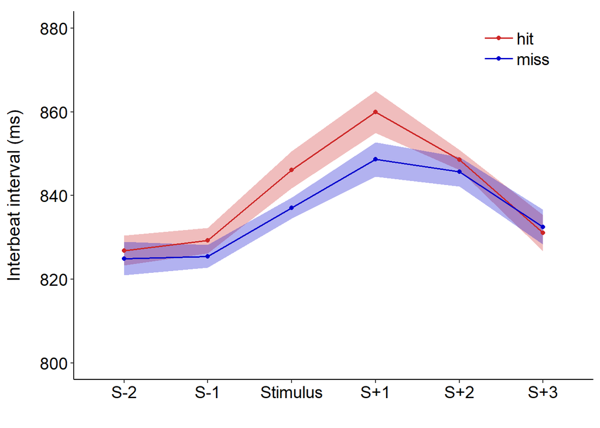

```r
## Create three functions used to calculate within-subjects variation. These fragments of code are credited to Winston Chang and were used and copied here under the CC0 license (http://www.cookbook-r.com/Graphs/Plotting_means_and_error_bars_(ggplot2)/#understanding-within-subjects-error-bars)

# Function 1: normDataWithin

normDataWithin <- function(data=NULL, idvar, measurevar, betweenvars=NULL, na.rm=FALSE, .drop=TRUE) {
    library(plyr)

    # Measure var on left, idvar + between vars on right of formula.
    data.subjMean <- ddply(data, c(idvar, betweenvars), .drop=.drop,
     .fun = function(xx, col, na.rm) {
        c(subjMean = mean(xx[,col], na.rm=na.rm))
      },
      measurevar,
      na.rm
    )

    # Put the subject means with original data
    data <- merge(data, data.subjMean)

    # Get the normalized data in a new column
    measureNormedVar <- paste(measurevar, "_norm", sep="")
    data[,measureNormedVar] <- data[,measurevar] - data[,"subjMean"] +
                               mean(data[,measurevar], na.rm=na.rm)

    # Remove this subject mean column
    data$subjMean <- NULL

    return(data)
}

# Function 2: summarySEwithin

summarySEwithin <- function(data=NULL, measurevar, betweenvars=NULL, withinvars=NULL, idvar=NULL, na.rm=FALSE, conf.interval=.95, .drop=TRUE) {

  # Ensure that the betweenvars and withinvars are factors
  factorvars <- vapply(data[, c(betweenvars, withinvars), drop=FALSE],
    FUN=is.factor, FUN.VALUE=logical(1))

  if (!all(factorvars)) {
    nonfactorvars <- names(factorvars)[!factorvars]
    message("Automatically converting the following non-factors to factors: ",
            paste(nonfactorvars, collapse = ", "))
    data[nonfactorvars] <- lapply(data[nonfactorvars], factor)
  }

  # Get the means from the un-normed data
  datac <- summarySE(data, measurevar, groupvars=c(betweenvars, withinvars),
                     na.rm=na.rm, conf.interval=conf.interval, .drop=.drop)

  # Drop all the unused columns (these will be calculated with normed data)
  datac$sd <- NULL
  datac$se <- NULL
  datac$ci <- NULL

  # Norm each subject's data
  ndata <- normDataWithin(data, idvar, measurevar, betweenvars, na.rm, .drop=.drop)

  # This is the name of the new column
  measurevar_n <- paste(measurevar, "_norm", sep="")

  # Collapse the normed data - now we can treat between and within vars the same
  ndatac <- summarySE(ndata, measurevar_n, groupvars=c(betweenvars, withinvars),
                      na.rm=na.rm, conf.interval=conf.interval, .drop=.drop)

  # Apply correction from Morey (2008) to the standard error and confidence interval
  #  Get the product of the number of conditions of within-S variables
  nWithinGroups    <- prod(vapply(ndatac[,withinvars, drop=FALSE], FUN=nlevels,
                           FUN.VALUE=numeric(1)))
  correctionFactor <- sqrt( nWithinGroups / (nWithinGroups-1) )

  # Apply the correction factor
  ndatac$sd <- ndatac$sd * correctionFactor
  ndatac$se <- ndatac$se * correctionFactor
  ndatac$ci <- ndatac$ci * correctionFactor

  # Combine the un-normed means with the normed results
  merge(datac, ndatac)
}

# Function 3: summarySE

summarySE <- function(data=NULL, measurevar, groupvars=NULL, na.rm=FALSE,
                      conf.interval=.95, .drop=TRUE) {
    library(plyr)

    # New version of length which can handle NA's: if na.rm==T, don't count them
    length2 <- function (x, na.rm=FALSE) {
        if (na.rm) sum(!is.na(x))
        else       length(x)
    }

    # This does the summary. For each group's data frame, return a vector with
    # N, mean, and sd
    datac <- ddply(data, groupvars, .drop=.drop,
      .fun = function(xx, col) {
        c(N    = length2(xx[[col]], na.rm=na.rm),
          mean = mean   (xx[[col]], na.rm=na.rm),
          sd   = sd     (xx[[col]], na.rm=na.rm)
        )
      },
      measurevar
    )

    # Rename the "mean" column
    datac <- rename(datac, c("mean" = measurevar))

    datac$se <- datac$sd / sqrt(datac$N)  # Calculate standard error of the mean

    # Confidence interval multiplier for standard error
    # Calculate t-statistic for confidence interval:
    # e.g., if conf.interval is .95, use .975 (above/below), and use df=N-1
    ciMult <- qt(conf.interval/2 + .5, datac$N-1)
    datac$ci <- datac$se * ciMult

    return(datac)
}

## Calculate within-subjects variation
d <- summarySEwithin(data=dat, measurevar = 'value', betweenvars=NULL, withinvars=c('time','awareness'), idvar='ID', na.rm=FALSE, conf.interval=.95, .drop=TRUE)

# Change into milliseconds
d$value <- d$value * 1000
d$ci <- d$ci * 1000

# Prepare descriptions
labs <- c("S-2", "S-1", "Stimulus", "S+1", "S+2", "S+3")

# Save awareness as factor
d$awareness <- factor(d$awareness)

## Plot associations between heart rate and perceptual performance over the course of a trial
pd <- position_dodge(0)
plot <- ggplot(d, aes(x=time, y=value,group=awareness,colour=awareness)) +
  geom_ribbon(aes(ymin=value-ci, ymax=value+ci, fill = factor(awareness)), position=pd, show.legend = F, alpha = 0.3, colour = NA) +
  scale_fill_manual(values=c("firebrick3", "blue3")) +
   geom_line(position=pd, size = 0.7)+
   geom_point(position=pd)+theme_classic()+
  labs(x = " ", y = "Interbeat interval (ms)") +
  scale_x_discrete(labels=labs) +
scale_y_continuous(limits=c(800,880)) +
  scale_color_manual(values=c("firebrick3", "blue3")) +
  coord_fixed(ratio = 0.05) +
  theme(legend.position= c(0.85,0.9)) +
  theme(legend.text = element_text(colour="black", size=14)) +
  theme(legend.title=element_blank()) +
  theme(legend.key.width = unit(1.05, "cm")) +
  theme(axis.title.y = element_text(size = 14.7, margin = margin(t = 0, r = 15, b = 0, l = 0))) +
  theme(axis.text=element_text(size=13.8, colour = "black"))
print(plot)
```

**10. Test differences in the extent of cardiac deceleration between hits and misses (Figure 4B)**

```r
# load required packages
require(ggplot2, warn.conflicts = FALSE, quietly=TRUE)
require(effsize, warn.conflicts = FALSE, quietly=TRUE)
require(reshape2, warn.conflicts = FALSE, quietly=TRUE)
source("https://gist.githubusercontent.com/benmarwick/2a1bb0133ff568cbe28d/raw/fb53bd97121f7f9ce947837ef1a4c65a73bffb3f/geom_flat_violin.R") # https://github.com/benmarwick
# Calculate difference between the RR interval when stimulus was delivered and the prior interval ("slope of heart rate change")
data$deceleration <- data$RR_int_zero_stimulus - data$RR_int_minus1

## Standardize cardiac deceleration into z-scores in each trial

# Derive participant-specific mean and SD of cardiac deceleration
for ( i in unique(data$ID)) { # LOOP PARTICIPANTS (i)
    dec_mean <- mean(data$deceleration[data$ID == i]) # mean
    dec_sd <- sd(data$deceleration[data$ID == i]) # SD

    for (b in unique(data$block[data$ID == i])) { # LOOP BLOCKS (b)
        for (t in unique(data$trial[data$ID == i & data$block == b])) { # LOOP TRIALS (t)

    # ascribe z-scored value to each trial
    data$dec[data$ID == i & data$block == b & data$trial == t] <- (data$dec[data$ID == i & data$block == b & data$trial == t] - dec_mean) / dec_sd
      } # END: LOOP TRIALS
    } # END: LOOP BLOCKS
} # END: LOOP PARTICIPANTS

## Specify a data frame with z-scored cardiac deceleration for hits and misse
data_ID <- data.frame(ID = integer(0),
                 dec_hit  = numeric(0),
                 dec_miss = numeric(0))

for ( i in unique(data$ID )) { # LOOP PARTICIPANTS (i)
    dec_miss <- mean(data$dec[data$ID == i & data$resp_class == "miss"]) # misses
    dec_hit <- mean(data$dec[data$ID == i & data$resp_class == "hit"]) # hits

    # Create the data frame
    data_ID[nrow(data_ID)+1,] <- c(i, dec_hit, dec_miss)
} # END: LOOP PARTICIPANTS

# Perform paired t test to compare the extent of cardiac deceleration between hits and misses
t.test(data_ID$dec_hit, data_ID$dec_miss, paired = T)
```

```
##
##  Paired t-test
##
## data:  data_ID$dec_hit and data_ID$dec_miss
## t = 6.9698, df = 32, p-value = 6.772e-08
## alternative hypothesis: true difference in means is not equal to 0
## 95 percent confidence interval:
##  0.1055308 0.1926846
## sample estimates:
## mean of the differences
##               0.1491077
```

```r
# Show effect size
cohen.d(data_ID$dec_hit, data_ID$dec_miss, paired = T)
```

```
##
## Cohen's d
##
## d estimate: 1.213288 (large)
## 95 percent confidence interval:
##       inf       sup
## 0.6781417 1.7484333
```

```r
# Show means and SD of cardiac decelerations
mean(data_ID$dec_hit) # mean hits
```

```
## [1] 0.07184382
```

```r
sd(data_ID$dec_hit) # SD hits
```

```
## [1] 0.07824312
```

```r
mean(data_ID$dec_miss) # mean misses
```

```
## [1] -0.07726393
```

```r
sd(data_ID$dec_miss) # SD misses
```

```
## [1] 0.06504319
```

```r
# Reshape the data frame
dat <- melt(data_ID, id.vars = c("ID"), measure.vars = c("dec_miss", "dec_hit"), variable.name = "time", value.name = "value")

## Prepare raincloud plots (Allen, Poggiali, Whitaker, Marshall, & Kievit, 2018) https://micahallen.org/2018/03/15/introducing-raincloud-plots/

# Calculate summary statistics for the plot
lb <- function(x) mean(x) - sd(x)
ub <- function(x) mean(x) + sd(x)

sumld <- dat %>%
  group_by(time) %>%
  summarise_all(funs(mean, median, lower = lb, upper = ub))
sumld
```

```
## # A tibble: 2 x 9
##   time  ID_mean value_mean ID_median value_median ID_lower value_lower
##   <fct>   <dbl>      <dbl>     <dbl>        <dbl>    <dbl>       <dbl>
## 1 dec_~      18    -0.0773        18      -0.0668     8.33    -0.142
## 2 dec_~      18     0.0718        18       0.0574     8.33    -0.00640
## # ... with 2 more variables: ID_upper <dbl>, value_upper <dbl>
```

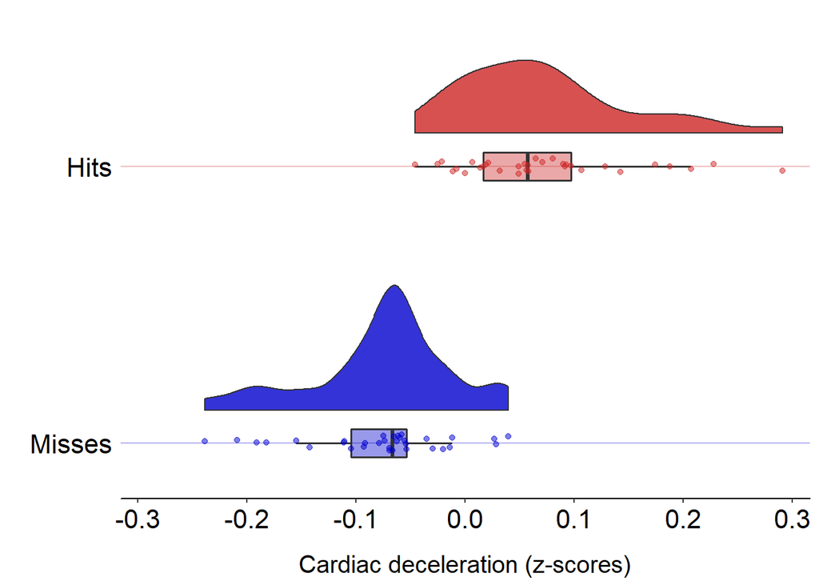

```r
# Specify theme of the plot
raincloud_theme <- theme(

  axis.text.x = element_text(angle = 0, vjust = 0.5),
  panel.border = element_blank(),
  panel.grid.minor = element_blank(),
  panel.grid.major = element_blank(),
  axis.line.x = element_line(colour = "black", size = 0.5, linetype = "solid"),
  axis.ticks.y = element_blank(),
  axis.line.y = element_blank())

# Specify parameters of the plot
cardiac_deceleration <-  ggplot(data = dat,
  aes(x = time, y = value, fill = time)) +
  geom_flat_violin(position = position_nudge(x = .12, y = 0), adjust = 1,  alpha = .8) +
  geom_vline(xintercept= 1, size = 0.5, color = "blue3", alpha = 0.3) +
  geom_vline(xintercept= 2, size = 0.5, color = "firebrick3", alpha = 0.3) +
   geom_boxplot(width = .1, outlier.shape = NA, alpha = 0.4, size = 0.6) +
  geom_point(aes(y = value, color = time), size = 1.5, colour = c(rep.int("blue3", 33), rep.int("firebrick3", 33)),
  position = position_jitter(width = .03), size = .4, alpha = 0.5) +
  expand_limits(x = 2) +
  guides(fill = FALSE) +
  guides(color = FALSE) +
  scale_x_discrete(labels= c("Misses", "Hits"), expand = c(0.2,0.0)) +
  scale_y_continuous(limits= c(-0.3, 0.3), breaks = c(-0.3,-0.2,-0.1,0,0.1,0.2,0.3), expand = c(0.01,0.01)) +
  labs(x = " ", y = "Cardiac deceleration (z-scores)") +
  scale_fill_manual(values = c("blue3", "firebrick3")) +
  coord_flip() +
  theme_bw() +
  theme(axis.text=element_text(size=16, colour = "black")) +
  theme(axis.title.x = element_text(size = 15, colour = "black", margin = margin(t = 15, r = 0, b = 0, l = 0))) + raincloud_theme
# Print the plot
cardiac_deceleration
```